# What is really driving the podcast listeners?

[figure not shown]

## Welcome to my visual data story

I work on a podcast that touches topics such as global economics and politics. The number of listeners vary all the time. I am curious to understand more about why this happens.

I created a csv file using google sheets that recorded input from a google form. I filled this form and later manipulated the data using R. I created some visual images to communicate my findings.

## Is the headline making people listen to the podcast?

I created two groups, one for the episodes that contain war-related words in its headline, and the other for those that don’t. As seen in the plot below, the amount of listeners is higher for the episodes that do contain war-related words in their headlines than for those that don’t. We can also see that there is more variance in the amount of listeners for the non-war episodes.

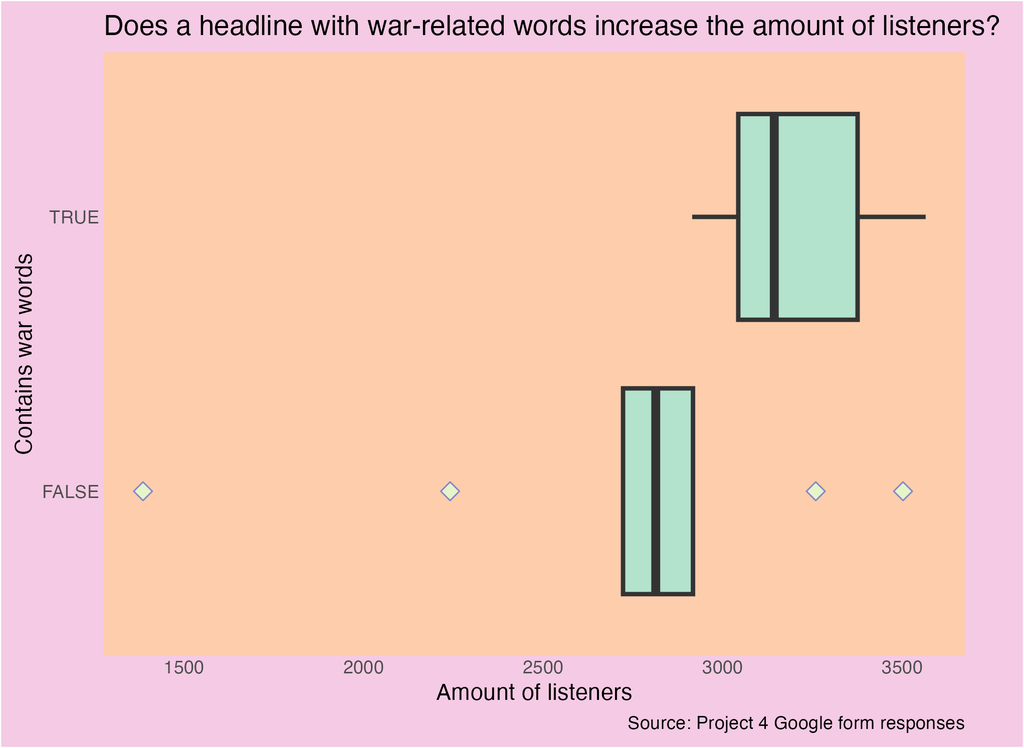

A plot showing the relationship between the podcast’s average listeners and the use of war-related words in its headline.

## Maybe the listeners have preferences over which economist in invited to talk.

There is a group of guest economists that are invited to talk. They rotate from episode to episode. I believe that listeners might have preferences for some economists over the others. In the bar plot below, we can see that indeed, some of them have higher average listeners than others. For example “Mahjabeen” has the highest average listeners.

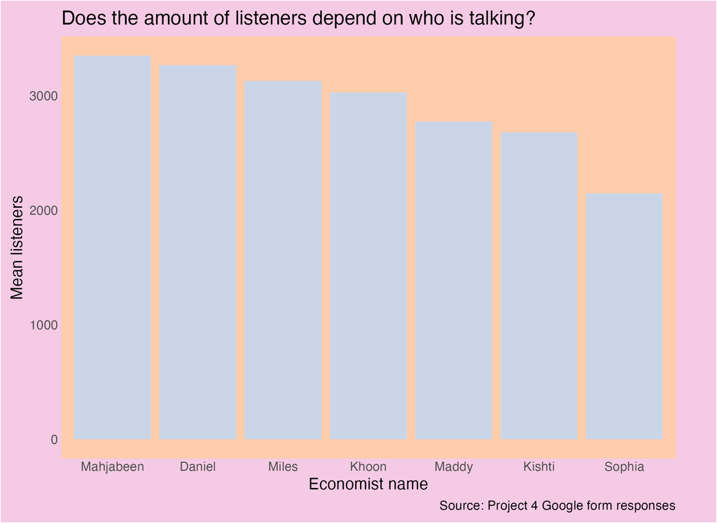

A bar-plot showing the relationship between the podcast’s amount of listeners and the name of the guest economist.

## Are there differences in the amount of listeners between the days of the week?

The traditional stock market opens from Mon-Fri (USA time) and closes during the weekend. Most of the listeners are stock market traders from Australia getting guidance on which trades to take. We can see that on Mondays, there are fewer listeners than on the rest of the days. This makes sense, as Mondays in Australia correspond to Sundays in USA and the stock market is closed. Additionally, it seems like Fridays are slightly lower than Tue - Wed - Thu. This was unexpected to me, maybe traders are more lazy on Fridays because TGIF?

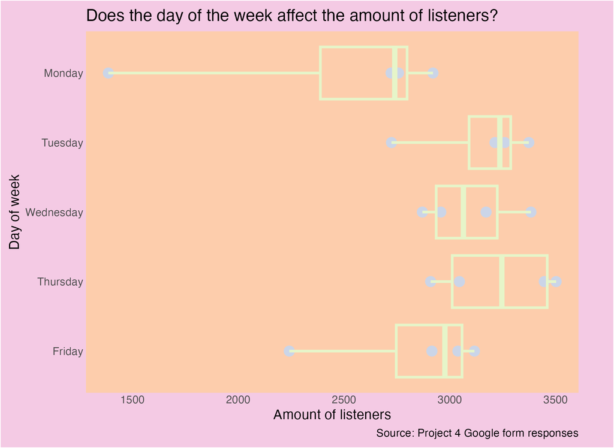

A box-plot showing the relationship between the podcast’s amount of listeners and the day of the week the podcast was aired

## Does the podcast have more listeners since I have done project 2?

The podcast is having more listeners in May 2026 (Project 4) as compared to those in March (Project 2). Anyone would be celebrating this, but I am not, because it means the war has escalated.

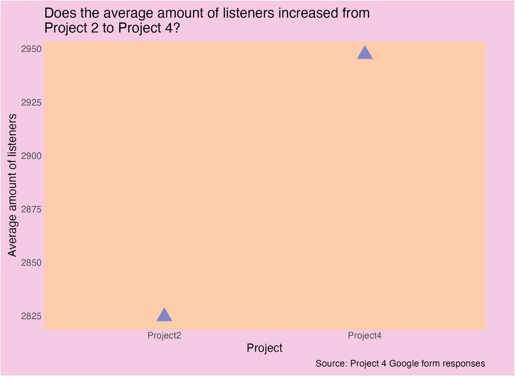

A scatter plot showing the average listeners of the podcast for observations taken for project 2 vs the average for project 4

## Top 4 podcasts!!

And to finish up on a nicer note, these are the top 4 podcasts that received the most listeners.

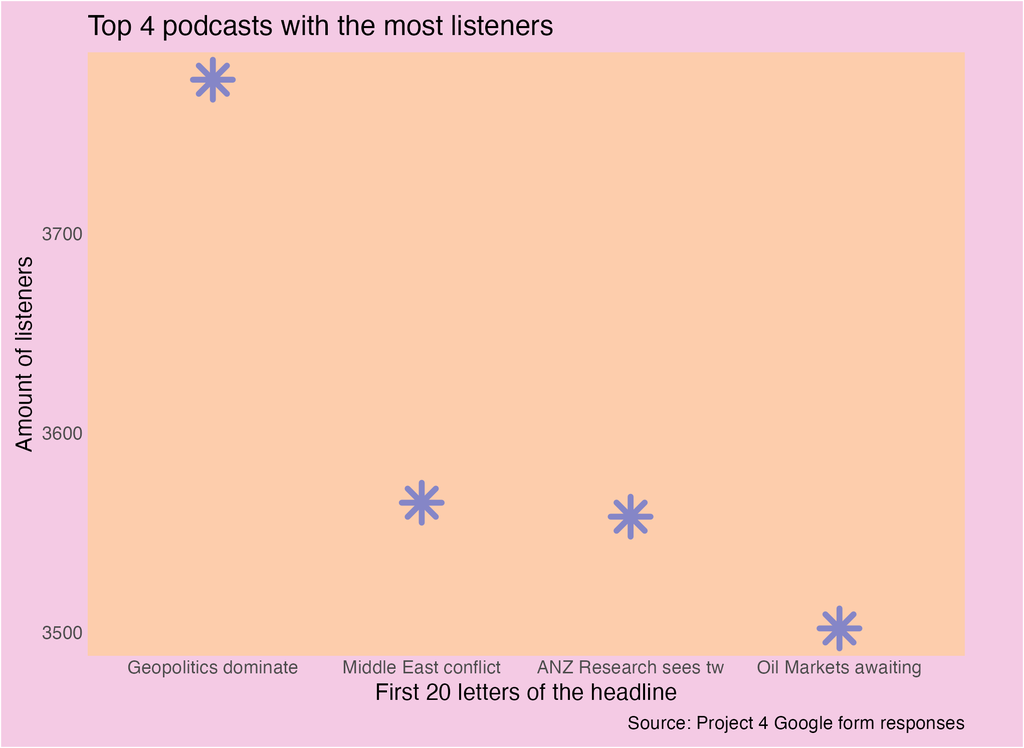

A scatter plot showing the top 4 podcast with the most listeners, and the first 20 letters of its headlne